# Quantitative Genetics of Behavior

# Literature Review

I performed a search on Web of Science for “quantitative gen$*$” AND behavio$*$ on 23 January 2018 and emailed all fo the results to myself. I copied the text of those emails into a text file and used my program `parse_wos` to extract the relevant fields: Publication type (PT), Full source title (SO), Authors (AU), Title (TI), Volume (VL), Publication year (PY), and abstract (AB). `parse_wos` output these fields as the columns of a tab-delimited file.

```r
source("../R/literature-review.R")
library(scales)
library(knitr)
orig.file<-data.frame(read.delim("qgb.txt",sep='\t',quote=""),stringsAsFactors = FALSE)
```

The web of science search resulted in 919 publications, which I saved in an Excel file and uploaded to Google Drive. In Google Drive I added columns to facilitate categorization and annotation of each abstract, and I added abstracts to those that did not have abstracts exported from Web of Science, when possible. Additionally, I removed any entries that did not pertain to evolutionary quantitative genetics and ignored studies on humans.

```r
qgb<-data.frame(read.csv("qgb.csv",header = TRUE),stringsAsFactors = FALSE)
qgb<-qgb[qgb$Human != "human",]
qgb<-search_line(c("none","not relevant","not behavior","not a behavior","not quantitative genetics","meeting abstract",
                       "not useful","plant","no abstract","just the abstract"),"Relevance.to.article",qgb,inverse = TRUE)
```

This annotated file contained 453 entries after the pruning mentioned above.

```r
synth<-c(grep("review",qgb$Methods), grep("synthesis",qgb$Methods),grep("meta.*analysis",qgb$Methods),
           grep("position p.*",qgb$Methods), grep("commentary",qgb$Methods), grep("intro.*issue",qgb$Methods))
syn<-qgb[synth[!duplicated(synth)],]
exp<-qgb[-synth[!duplicated(synth)],]
models<-c(grep("^model",exp$Methods),grep("stats",exp$Methods),grep("mathematical",exp$Methods),grep("statistical",exp$Methods),
           grep("evolutionary model",exp$Methods),grep("theoretical model",exp$Methods), grep("simulation model",exp$Methods),
           grep("game theoretic model",exp$Methods))
mod<-exp[models[!duplicated(models)],]
exp<-exp[-models[!duplicated(models)],]
```

Of those, 135 were review, synthesis, commentaries, and meta-analyses. 56 papers were theoretical or statistical models, and the remaining 262 were laboratory or field estimates of quantitative genetic parameters of behavioral phenotypes.

## Experimental design

What experimental designs were used, and how frequently?

```r
paroff<-count_lines(keywords = "parent-offspring regression",column.name = "Method.classification",dat=exp)
#sibs
fullsib<-count_lines(keywords = "full-sib",column.name = "Method.classification",dat=exp,
                    remwords=c("cross-foster","common-garden","half/","selection"))
halfsib<-count_lines(keywords = "half-sib",column.name = "Method.classification",dat=exp,
                    remwords=c("cross-foster","common-garden","/full","selection"))
halfful<-count_lines(keywords = "half/full-sib",column.name = "Method.classification",dat=exp,
                    remwords=c("cross-foster","common-garden","selection"))
crfossib<-count_lines(keywords = "cross-foster",column.name = "Method.classification",dat=exp,
                      remwords=c("pedigree","F2"))
cgsib<-count_lines(keywords = "common-garden",column.name = "Method.classification",dat=exp)
#clones
clones<-count_lines(keywords = "clones",column.name = "Method.classification",dat=exp)
#cross-classified
factorial<-count_lines(keywords = "factorial",column.name = "Method.classification",dat=exp)
diallel<-count_lines(keywords = "diallel",column.name = "Method.classification",dat=exp)
backcross<-count_lines(keywords = "backcross",column.name = "Method.classification",dat=exp)
reciprocal<-count_lines(keywords = c("reciprocal","recirpocal"),column.name = "Method.classification",
                        dat=exp,"selection")
inbred<-count_lines(keywords = c("inbred","F\\d+"),column.name = "Method.classification",dat=exp,
                    remwords=c("backcross","reciprocal"))
crsfosf2<-count_lines(keywords = "cross-foster.*F2",column.name = "Method.classification",dat=exp)
#selection
selection<-count_lines(keywords =c("experiment", "selection"),column.name = "Method.classification",dat=exp)
#relatedness
pedigree<-count_lines(keywords = "pedigree",column.name = "Method.classification",dat=exp)
relatedness<-count_lines(keywords = "relatedness",column.name = "Method.classification",dat=exp)
#other
phenotype<-count_lines(keywords = "phenotypes",column.name = "Method.classification",dat=exp)
repeatability<-count_lines(keywords = "repeatability",column.name = "Method.classification",dat=exp)
other<-count_lines(".*","Method.classification",exp,
                   remwords=c("parent-offspring regression","full-sib","half-sib","half/full-sib",
                              "cross-foster","common-garden","clones","factorial","diallel","inbred",
                              "selection","pedigree","relatedness","QTL","GWAS","reciprocal",
                              "backcross","recirpocal","experiment","phenotype","repeatability","F\\d+"))
#QTL/GWAS
qtl<-count_lines(keywords = "QTL",column.name = "Method.classification",dat=exp)
gwas<-count_lines(keywords = "GWAS",column.name = "Method.classification",dat=exp)

kable(data.frame(Experiment=c("Parent-offspring Regression","Full-sib","Half-sib",
                              "Half and full-sib","Cross foster","Common garden",
                              "clones","factorial","inbred","backcross","reciprocal",
                              "diallel","selection","pedigree","relatedness","phenotype",
                              "repeatability","other","qtl","gwas"),
                 Counts=c(paroff,fullsib,halfsib,halfful,crfossib,cgsib,
                          clones,factorial,diallel,backcross,reciprocal,
                          inbred,selection,pedigree,relatedness,phenotype,
                          repeatability, other,qtl,gwas)))
```

| Experiment | Counts |
| --- | --- |
| Parent-offspring Regression | 12 |
| Full-sib | 15 |
| Half-sib | 16 |
| Half and full-sib | 10 |
| Cross foster | 12 |
| Common garden | 10 |
| clones | 6 |
| factorial | 7 |
| inbred | 9 |
| backcross | 10 |
| reciprocal | 2 |
| diallel | 51 |
| selection | 30 |
| pedigree | 40 |
| relatedness | 7 |
| phenotype | 9 |
| repeatability | 7 |
| other | 17 |
| qtl | 19 |
| gwas | 5 |

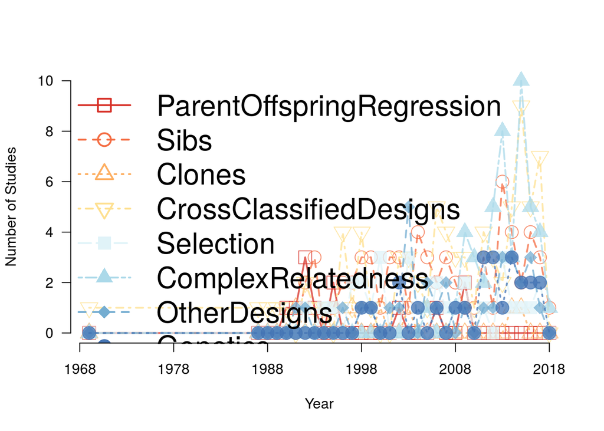

```r
regression<-search_line(keywords = "parent-offspring regression",column.name = "Method.classification",dat=exp)
#sibs
sibs<-search_line(keywords = c("cross-foster","sib","common-garden"),
                  column.name = "Method.classification",dat=exp,
                    remwords=c("pedigree","F2","selection","experiment"))
#clones
clones<-search_line(keywords = "clones",column.name = "Method.classification",dat=exp)
#cross-classified
crosses<-search_line(keywords = c("factorial","diallel","backcross","reciprocal","recirpocal",
                                  "inbred","F\\d+", "cross-foster.*F2"),
                     column.name = "Method.classification",dat=exp)
#selection
selection<-search_line(keywords =c("experiment", "selection"),column.name = "Method.classification",dat=exp)
#relatedness
complex<-search_line(keywords = c("pedigree","relatedness"),column.name = "Method.classification",dat=exp)
#other
other<-search_line(c(".*","phenotypes","repeatability"),"Method.classification",exp,
                   remwords=c("parent-offspring regression","full-sib","half-sib","half/full-sib",
                              "cross-foster","common-garden","clones","factorial","diallel","inbred",
                              "selection","pedigree","relatedness","QTL","GWAS","reciprocal",
                              "backcross","recirpocal","experiment","F\\d+"))
#genetics
genetics<-search_line(keywords = c("QTL","GWAS"),column.name = "Method.classification",dat=exp)


#plot it
yrs<-do.call(rbind,lapply(levels(factor(exp$PY)),function(year){
  df<-data.frame(ParentOffspringRegression=nrow(regression[regression$PY==year,]),
                 Sibs=nrow(sibs[sibs$PY==year,]),
                 Clones=nrow(clones[clones$PY==year,]),
                 CrossClassifiedDesigns=nrow(crosses[crosses$PY==year,]),
                 Selection=nrow(selection[selection$PY==year,]),
                 ComplexRelatedness=nrow(complex[complex$PY==year,]),
                 OtherDesigns=nrow(other[other$PY==year,]),
                 Genetics=nrow(genetics[genetics$PY==year,]))
}))
rownames(yrs)<-levels(factor(exp$PY))
cols<-c('#d73027','#f46d43','#fdae61','#fee090','#e0f3f8','#abd9e9','#74add1','#4575b4')
names(cols)<-colnames(yrs)
ltys<-c(1:6,2,3)
names(ltys)<-colnames(yrs)
pchs<-c(0,1,2,6,15,17:19)
plot(range(levels(factor(exp$PY))),c(0,max(yrs)),bty='l',type = 'n',
     xlab="Year",ylab="Number of Studies",axes=FALSE)
for(i in 1:ncol(yrs)){
  points(levels(factor(exp$PY)),yrs[,i],col=alpha(cols[i],0.75),pch=pchs[i],cex=2)
  lines(levels(factor(exp$PY)),yrs[,i],col=alpha(cols[i],0.75),lty=ltys[i],lwd=2)
}
legend("topleft",colnames(yrs),col=cols,lty=ltys,bty='n',lwd=2,pch=pchs,cex=2)
axis(1,at=seq(1968,2018,10))
axis(2,las=1)
```

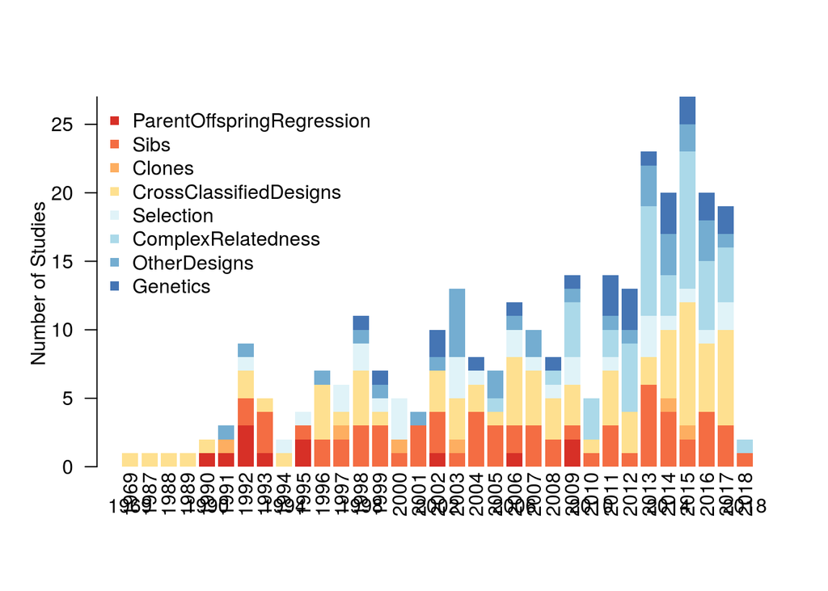

```r
#try a bar chart
bp<-barplot(t(yrs),col=cols,border = NA,axes=FALSE)
legend("topleft",colnames(yrs),col=cols,bty='n',pch=15)
text(label=rownames(yrs),bp,-2,xpd=TRUE,srt=90)
axis(2,las=1,at=seq(0,30,5))
mtext("Number of Studies",2,line=2)
```

## Species

How are these studies distributed across species/taxa/classes?

```r
kable(table(factor(exp$species))[order(table(factor(exp$species)),decreasing = TRUE)],col.names = c("Species name","Number of studies"))
```

| Species name | Number of studies |
| --- | --- |
| Drosophila melanogaster | 29 |
| Mus musculus | 22 |
| Taeniopygia guttata | 9 |
| Caenorhabditis elegans | 6 |
| Parus major | 6 |
| Callosobruchus maculatus | 5 |
| Gryllus firmus | 5 |
| Marmota flaviventris | 5 |
| Mus doemsticus | 5 |
| Passer domesticus | 5 |
| Gallus gallus domesticus | 4 |
| Nicrophorus vespilloides | 4 |
| Plutella xylostella | 4 |
| Tetranychus urticae | 4 |
| Cyanistes caeruleus | 3 |
| Macaca mulatta | 3 |
| Poecilia reticulata | 3 |
| Rattus norvegicus | 3 |
| Tribolium castaneum | 3 |
| Apis | 2 |
| Astyanax mexicanus | 2 |
| Blattella germanica | 2 |
| Bos taurus | 2 |
| Cichlidae | 2 |
| Danio rerio | 2 |
| Dicentrarchus labrax | 2 |
| Gasterosteus aculeatus | 2 |
| Gerris lacustris | 2 |
| Gryllus bimaculatus | 2 |
| Gryllus campestris | 2 |

[output cut: 102 more lines]

```r
kable(table(factor(exp$common.name))[order(table(factor(exp$common.name)),decreasing = TRUE)],col.names = c("Common name","Number of studies"))
```

| Common name | Number of studies |
| --- | --- |
| fruit fly | 32 |
| mouse | 22 |
| zebra finch | 9 |
| great tits | 6 |
| roundworm | 6 |
| cricket | 5 |
| house mouse | 5 |
| house sparrows | 5 |
| yellow-bellied marmots | 5 |
| blue tits | 4 |
| burying beetle | 4 |
| chickens | 4 |
| diamondback moth | 4 |
| water flea | 4 |
| rats | 3 |
| seed beetle | 3 |
| Trinidadian guppies | 3 |
| two-spotted spider mite | 3 |
| Chinook salmon | 2 |
| dairy cows | 2 |
| deer mice | 2 |
| dung fly | 2 |
| European seabass | 2 |
| field crickets | 2 |
| garter snake | 2 |
| German cockroach | 2 |
| honeybee | 2 |
| housefly | 2 |
| Mediterranean field cricket | 2 |
| Mexican cavefish | 2 |

[output cut: 101 more lines]

```r
kable(table(factor(exp$Class))[order(table(factor(exp$Class)),decreasing = TRUE)],col.names = c("Class","Number of studies"))
```

| Class | Number of studies |
| --- | --- |
| Insecta | 106 |
| Mammalia | 53 |
| Aves | 40 |
| Actinopterygii | 25 |
| Arachnida | 9 |
| Amphibia | 7 |
| Chromadorea | 6 |
| Reptilia | 6 |
| Branchiopoda | 4 |
| Gastropoda | 2 |
| Malacostraca | 2 |
| Chlorophyceae | 1 |
| Rhabditophora | 1 |

```r
# Creating a table in the format that I want, with class and species and number of studies.
spp<-data.frame(table(factor(exp$species))[order(table(factor(exp$species)),decreasing = TRUE)])
colnames(spp)<-c("Species","Number.of.studies")
spp$Class<-unlist(lapply(spp$Species,function(sp,df){
  unique(df[df$species %in% sp,"Class"])
},df=exp))
cls<-data.frame(table(factor(exp$Class))[order(table(factor(exp$Class)),decreasing = TRUE)])
colnames(cls)<-c("Class","Number.of.studies")
cls<-data.frame(Species="All",Number.of.studies=cls$Number.of.studies,Class=cls$Class,stringsAsFactors = FALSE)
spcl<-data.frame(rbind(spp,cls),stringsAsFactors = FALSE)
write.table(spcl[order(spcl$Class,spcl$Number.of.studies,decreasing=TRUE),c(3,1,2)],"qgbSpeciesClass.csv",row.names=FALSE,sep=",")
```

## Categories

Of the experimental ones, how do they break down into categories? These categories are not mutually exclusive, and any one study may belong to multiple categories.

```r
cats<-count_filled_lines(exp,16:(ncol(exp)-1))#apply(exp[,16:(ncol(exp)-1)],2,function(c){ length(c[c!=""])})
kable(cats[order(cats,decreasing = TRUE)],col.names = "Number of studies")
```

|  | Number of studies |
| --- | --- |
| Personality | 58 |
| Reproduction.and.Fecundity | 45 |
| Mate.choice.and.Sexual.selection | 43 |
| Locomotion | 35 |
| Foraging | 33 |
| Life.history | 33 |
| Social.behavior | 27 |
| IGE | 27 |
| Communication | 22 |
| Plasticity | 20 |
| GxE | 20 |
| Predator.avoidance | 17 |
| Parental.Care | 14 |
| Learning | 12 |
| Migration | 11 |
| Phenotypic.gambit | 8 |
| Cooperation | 1 |

```r
write.table(cats[order(cats,decreasing = TRUE)],"QGB_categories.csv",sep=",")
```

“Reproduction and Fecundity” includes reproductive success and reproductive strategies, such as asexual/sexual/hermaphroditic sexual systems, monogamy vs polygyny, alternative mate choice tactics, oviposition/nesting preferences and timing, egg and milk production traits, physiological effects of mating, and other fecundity-related phenotypes. “Mate choice and sexual selection” includes pre and postcopulatory selective episodes as well as elements of display traits (e.g., male song in crickets) and female preferences.

Clearly personality traits have been widely studied.

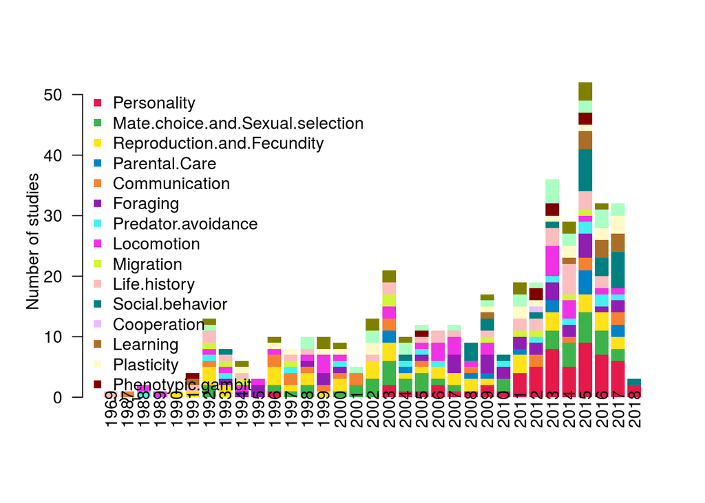

```r
catyrs<-do.call(rbind,lapply(levels(factor(exp$PY)),function(year,exp,cats){
  yr<-exp[exp$PY==year,]
  cnts<-apply(yr[,names(cats)],2,function(d){ length(d[d!=""])})
  return(cnts)
},exp=exp,cats=cats))

color <- c("#e6194b","#3cb44b","#ffe119","#0082c8","#f58231","#911eb3","#46f0f0","#f032e6","#d2f53c",
           "#fabebe","#008080","#e6beff","#aa6e28","#fffac8","#800000","#aaffc3","#808000","#ffd8b1",
           "#000080","#808080","#FFFFFF","#000000")
#Don't include this one
col<-color[1:length(catyrs)]
bp<-barplot(t(catyrs),
            col=col,las=1,border = NA,axes = FALSE)
legend("topleft",colnames(catyrs),
       col=col,bty='n',pch=15)
axis(2,las=1,at=seq(0,50,10))
text(bp,-2,xpd=TRUE,srt=90,labels = levels(factor(exp$PY)))
mtext("Number of studies",2,line=2)
```

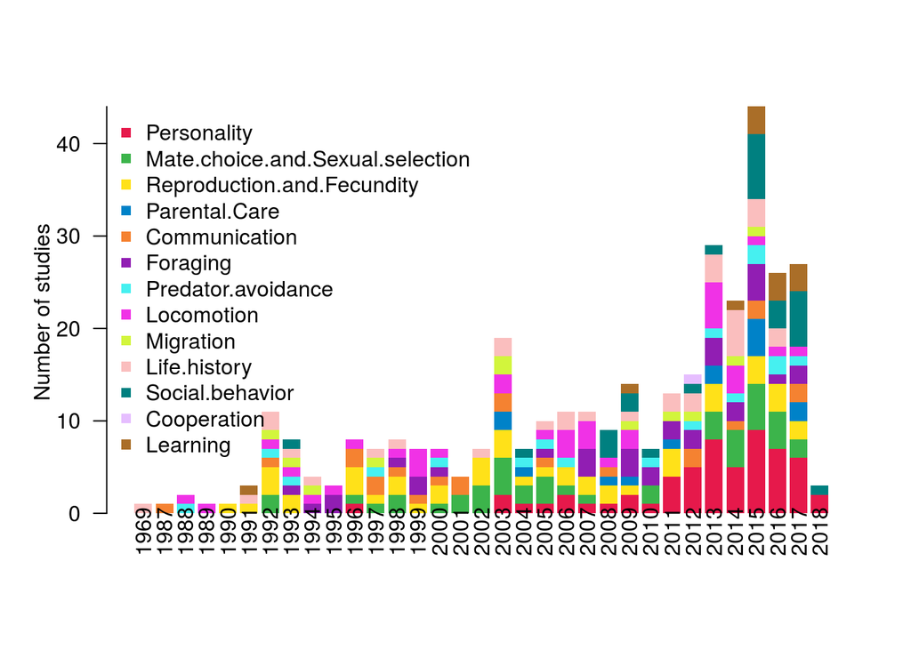

```r
col<-color[1:length(catyrs[,!colnames(catyrs)%in%c("Plasticity","Phenotypic.gambit","IGE","GxE")])]
bp<-barplot(t(catyrs[,!colnames(catyrs)%in%c("Plasticity","Phenotypic.gambit","IGE","GxE")]),
            col=col,las=1,border = NA,axes = FALSE)
legend("topleft",colnames(catyrs[,!colnames(catyrs)%in%c("Plasticity","Phenotypic.gambit","IGE","GxE")]),
       col=col,bty='n',pch=15)
axis(2,las=1,at=seq(0,50,10))
text(bp,-2,xpd=TRUE,srt=90,labels = levels(factor(exp$PY)))
mtext("Number of studies",2,line=2)
```

### Personality

Let’s focus on personality studies

```r
pers<-qgb[qgb$Personality!="",]
synth<-c(grep("review",pers$Methods), grep("synthesis",pers$Methods),grep("meta.*analysis",pers$Methods),
           grep("position p.*",pers$Methods), grep("commentary",pers$Methods), grep("intro.*issue",pers$Methods))
psyn<-pers[synth[!duplicated(synth)],]
pexp<-pers[-synth[!duplicated(synth)],]
models<-c(grep("^model",pexp$Methods),grep("stats",pexp$Methods),grep("mathematical",pexp$Methods),grep("statistical",pexp$Methods),
           grep("evolutionary model",pexp$Methods),grep("theoretical model",pexp$Methods), grep("simulation model",pexp$Methods),
           grep("game theoretic model",pexp$Methods))
pmod<-pexp[models[!duplicated(models)],]
pexp<-pexp[-models[!duplicated(models)],]
```

Of those, 27 were review, synthesis, commentaries, and meta-analyses. 2 papers were theoretical or statistical models, and the remaining 58 were laboratory or field estimates of quantitative genetic parameters of behavioral phenotypes.

```r
kable(table(factor(pexp$species))[order(table(factor(pexp$species)),decreasing = TRUE)],col.names = c("Species name","Number of studies"))
```

| Species name | Number of studies |
| --- | --- |
| Drosophila melanogaster | 5 |
| Parus major | 5 |
| Marmota flaviventris | 4 |
| Passer domesticus | 4 |
| Cyanistes caeruleus | 3 |
| Macaca mulatta | 3 |
| Danio rerio | 2 |
| Gallus gallus domesticus | 2 |
| Gasterosteus aculeatus | 2 |
| Gerris lacustris | 2 |
| Gryllus integer | 2 |
| Taeniopygia guttata | 2 |
| Apis | 1 |
| Asellus aquaticus | 1 |
| Bos taurus | 1 |
| Bos taurus and Ovis | 1 |
| Callosobruchus maculatus | 1 |
| Canis lupus | 1 |
| Cyanistes caeruleus | 1 |
| Dicentrarchus labrax | 1 |
| Diomedea exulans | 1 |
| Glycyphagus privatus and G. ornatus | 1 |
| Gryllus campestris | 1 |
| Lucania goodei | 1 |
| Mus musculus | 1 |
| Octodon degus | 1 |
| Ovis canadensis | 1 |
| Pseudophryne corroboree | 1 |
| Rattus norvegicus | 1 |
| Salmo trutta | 1 |
| Tamiasciurus hudsonicus | 1 |
| Triturus montandoni | 1 |
| Xiphophorus | 1 |
| Xiphophorus birchmanni | 1 |

```r
kable(table(factor(pexp$common.name))[order(table(factor(pexp$common.name)),decreasing = TRUE)],col.names = c("Common name","Number of studies"))
```

| Common name | Number of studies |
| --- | --- |
| fruit fly | 5 |
| great tits | 5 |
| blue tits | 4 |
| house sparrows | 4 |
| yellow-bellied marmots | 4 |
| chickens | 2 |
| rhesus macaques | 2 |
| three-spined stickleback | 2 |
| water striders | 2 |
| western stutter-trilling cricket | 2 |
| zebra finch | 2 |
| zebrafish | 2 |
| bighorn sheep | 1 |
| bluefin killifish | 1 |
| brown trout | 1 |
| common degu | 1 |
| dairy cows | 1 |
| European seabass | 1 |
| farm animals | 1 |
| field crickets | 1 |
| golden retriever dogs | 1 |
| honeybee | 1 |
| isopod | 1 |
| mites | 1 |
| Montandnon’s newt | 1 |
| mouse | 1 |
| North American red squirrels | 1 |
| rats | 1 |
| Rhesus macaque | 1 |
| seed beetle | 1 |
| sheepshead swordtails | 1 |
| southern corroboree frogs | 1 |
| swordtails | 1 |
| wandering albatross | 1 |

```r
kable(table(factor(pexp$Class))[order(table(factor(pexp$Class)),decreasing = TRUE)],col.names = c("Class","Number of studies"))
```

| Class | Number of studies |
| --- | --- |
| Aves | 18 |
| Mammalia | 15 |
| Insecta | 12 |
| Actinopterygii | 9 |
| Amphibia | 2 |
| Arachnida | 1 |
| Malacostraca | 1 |

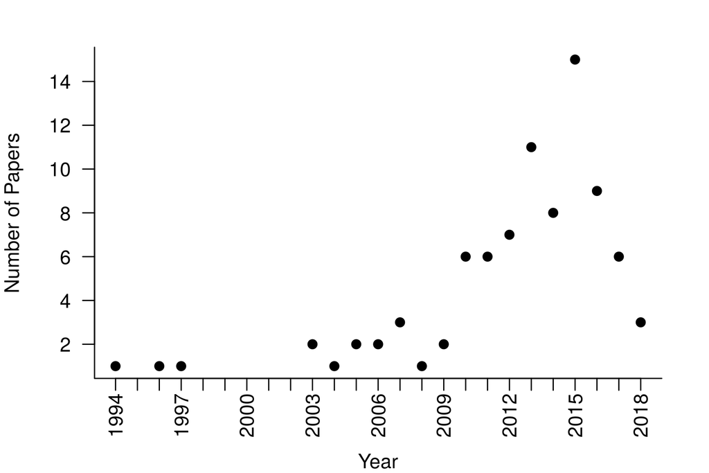

Personality Timeline

```r
pery<-data.frame(table(pers$PY))
colnames(pery)<-c("Year","NumPapers")

png("figs/Personality_Timeline.png",height=4,width=6,units="in",res=300)
par(mar=c(4,4,2,2))
plot(as.numeric(as.character(pery$Year)),pery$NumPapers,bty='l',xlab="Year",ylab="Number of Papers",
     xaxt='n',pch=19,las=1)
axis(1,at=seq(min(as.numeric(as.character(pery$Year))),max(as.numeric(as.character(pery$Year)))),labels = NA)
text(x=seq(min(as.numeric(as.character(pery$Year))),max(as.numeric(as.character(pery$Year))),3),y=-1.25,
     xpd=TRUE,srt=90,labels = seq(min(as.numeric(as.character(pery$Year))),max(as.numeric(as.character(pery$Year))),3))
dev.off()
```

### Plasticity

I found 20 studies that investigated plasticity, either explicitly setting out to do so or finding it emerge. I’d like to see how plasticity overlaps with other categories.

```r
plasticity<-exp[exp$Plasticity!="",]
cnt<-count_filled_lines(plasticity,16:(ncol(plasticity)-1))
#or proportionally
prp<-count_filled_lines(plasticity,16:(ncol(plasticity)-1))/nrow(exp[exp$Plasticity!="",])
kable(data.frame(names(cnt),cnt,prp,stringsAsFactors = FALSE),
      col.names = c("Category","Number of studies","Proportion of those with plasticity"),row.names=FALSE)
```

| Category | Number of studies | Proportion of those with plasticity |
| --- | --- | --- |
| Personality | 6 | 0.30 |
| Mate.choice.and.Sexual.selection | 3 | 0.15 |
| Reproduction.and.Fecundity | 3 | 0.15 |
| Parental.Care | 1 | 0.05 |
| Communication | 1 | 0.05 |
| Foraging | 3 | 0.15 |
| Predator.avoidance | 3 | 0.15 |
| Locomotion | 2 | 0.10 |
| Migration | 1 | 0.05 |
| Life.history | 3 | 0.15 |
| Social.behavior | 2 | 0.10 |
| Cooperation | 0 | 0.00 |
| Learning | 4 | 0.20 |
| Plasticity | 20 | 1.00 |
| Phenotypic.gambit | 0 | 0.00 |
| IGE | 3 | 0.15 |
| GxE | 5 | 0.25 |

### IGE

I found 27 studies that investigated IGE, either explicitly setting out to do so or finding it emerge. I’d like to see how IGE overlaps with other categories.

```r
ige<-exp[exp$IGE!="",]
cnt<-count_filled_lines(ige,16:(ncol(ige)-1))
#or proportionally
prp<-count_filled_lines(ige,16:(ncol(ige)-1))/nrow(exp[exp$IGE!="",])
kable(data.frame(names(cnt),cnt,prp,stringsAsFactors = FALSE),
      col.names = c("Category","Number of studies","Proportion of those with plasticity"),row.names=FALSE)
```

| Category | Number of studies | Proportion of those with plasticity |
| --- | --- | --- |
| Personality | 6 | 0.2222222 |
| Mate.choice.and.Sexual.selection | 6 | 0.2222222 |
| Reproduction.and.Fecundity | 4 | 0.1481481 |
| Parental.Care | 2 | 0.0740741 |
| Communication | 1 | 0.0370370 |
| Foraging | 1 | 0.0370370 |
| Predator.avoidance | 2 | 0.0740741 |
| Locomotion | 5 | 0.1851852 |
| Migration | 0 | 0.0000000 |
| Life.history | 3 | 0.1111111 |
| Social.behavior | 4 | 0.1481481 |
| Cooperation | 0 | 0.0000000 |
| Learning | 0 | 0.0000000 |
| Plasticity | 3 | 0.1111111 |
| Phenotypic.gambit | 0 | 0.0000000 |
| IGE | 27 | 1.0000000 |
| GxE | 2 | 0.0740741 |

### GxE

I found 20 studies that investigated GxE effects, either explicitly setting out to do so or finding it emerge. I’d like to see how GxE overlaps with other categories.

```r
gxe<-exp[exp$GxE!="",]
cnt<-count_filled_lines(gxe,16:(ncol(gxe)-1))
#or proportionally
prp<-count_filled_lines(gxe,16:(ncol(gxe)-1))/nrow(exp[exp$GxE!="",])
kable(data.frame(names(cnt),cnt,prp,stringsAsFactors = FALSE),
      col.names = c("Category","Number of studies","Proportion of those with plasticity"),row.names=FALSE)
```

| Category | Number of studies | Proportion of those with plasticity |
| --- | --- | --- |
| Personality | 4 | 0.20 |
| Mate.choice.and.Sexual.selection | 5 | 0.25 |
| Reproduction.and.Fecundity | 0 | 0.00 |
| Parental.Care | 2 | 0.10 |
| Communication | 1 | 0.05 |
| Foraging | 8 | 0.40 |
| Predator.avoidance | 1 | 0.05 |
| Locomotion | 3 | 0.15 |
| Migration | 3 | 0.15 |
| Life.history | 4 | 0.20 |
| Social.behavior | 0 | 0.00 |
| Cooperation | 0 | 0.00 |
| Learning | 2 | 0.10 |
| Plasticity | 5 | 0.25 |
| Phenotypic.gambit | 0 | 0.00 |
| IGE | 2 | 0.10 |
| GxE | 20 | 1.00 |

## Combine plots

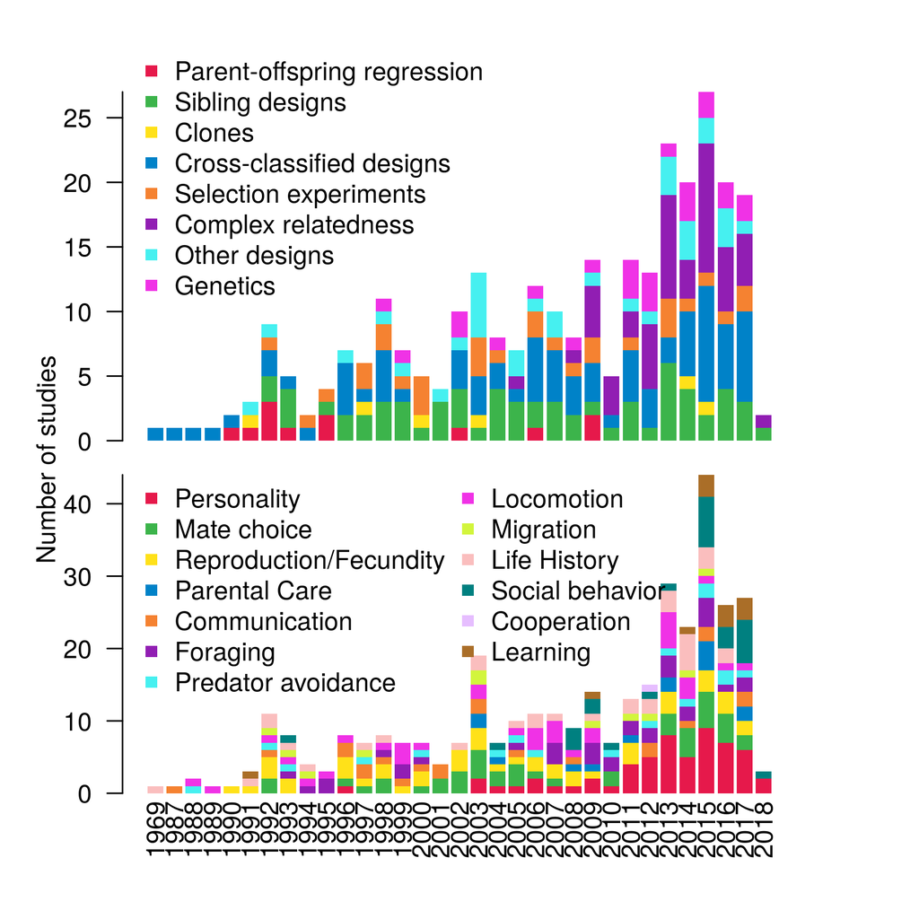

Combined plots

```r
png("figs/YearPlots.png",height=6,width=6,res=300,units="in")
par(mfrow=c(2,1),mar=c(0.5,2,1,2),oma=c(2,2,2,2))
cols<-color[1:ncol(yrs)]
bp<-barplot(t(yrs),col=cols,border = NA,axes=FALSE,xaxt='n')
legend(x = -1,y=31,c("Parent-offspring regression","Sibling designs","Clones","Cross-classified designs",
                     "Selection experiments","Complex relatedness","Other designs", "Genetics"),
       col=cols,bty='n',pch=15,xpd=TRUE)
#text(label=rownames(yrs),bp,-3,xpd=TRUE,srt=90)
axis(2,las=1,at=seq(0,30,5))
par(mar=c(2,2,0.5,2))
col<-color[1:length(colnames(catyrs)[!colnames(catyrs)%in%c("Plasticity","Phenotypic.gambit","IGE","GxE")])]
bp<-barplot(t(catyrs[,!colnames(catyrs)%in%c("Plasticity","Phenotypic.gambit","IGE","GxE")]),
            col=col,las=1,border = NA,axes = FALSE)
legend(x = -1,y=45,c("Personality","Mate choice","Reproduction/Fecundity","Parental Care",
                   "Communication","Foraging","Predator avoidance", "Locomotion", "Migration",
                   "Life History","Social behavior", "Cooperation","Learning"),
       col=col,bty='n',pch=15,ncol=2)
axis(2,las=1,at=seq(0,50,10))
text(bp,-5,xpd=TRUE,srt=90,labels = levels(factor(exp$PY)))
mtext("Number of studies",2,outer=TRUE)
dev.off()
```